# Case study: Measles in large and small towns

Aaron A. King

[Licensed under the Creative Commons Attribution-NonCommercial license](http://creativecommons.org/licenses/by-nc/4.0/). Please share and remix noncommercially, mentioning its origin.

Produced in **R** version 3.6.1 using **pomp** version 2.2.2.0.

## Objectives

1. To display a published case study using plug-and-play methods with non-trivial model complexities.
2. To show how extra-demographic stochasticity can be modeled.
3. To demonstrate the use of covariates in **pomp**.
4. To demonstrate the use of profile likelihood in scientific inference.
5. To discuss the interpretation of parameter estimates.
6. To emphasize the potential need for extra sources of stochasticity in modeling.

## Measles revisited

### Motivation: challenges in inference from disease dynamics

- Understanding, forecasting, managing epidemiological systems increasingly depends on models.
- Dynamic models can be used to test causal hypotheses.
- Real epidemiological systems:
  - are nonlinear
  - are stochastic
  - are nonstationary
  - evolve in continuous time
  - have hidden variables
  - can be measured only with (large) error
- Dynamics of infectious disease outbreaks illustrate this well.
- Measles is the paradigm for a nonlinear ecological system that can be well described by low-dimensional nonlinear dynamics.
- A tradition of careful modeling studies have proposed and found evidence for a number of specific mechanisms, including
  - a high value of $R_0$ (c. 15–20)
  - under-reporting
  - seasonality in transmission rates associated with school terms
  - response to changing birth rates
  - a birth-cohort effect
  - metapopulation dynamics
  - fadeouts and reintroductions that scale with city size
  - spatial traveling waves
- Much of this evidence has been amassed from fitting models to data, using a variety of methods.
- See Rohani and King (2010) for a review of some of the high points.

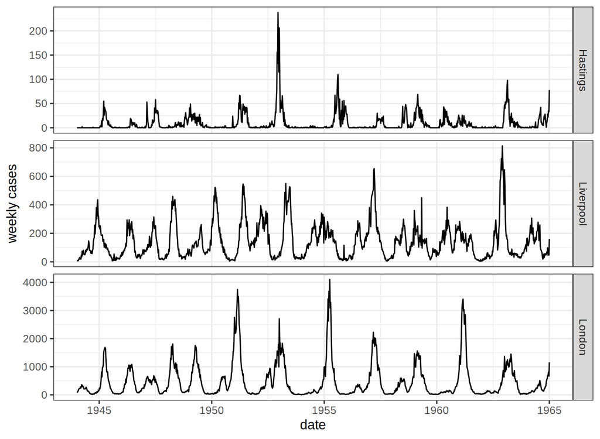

### Outline

- We revisit a classic measles data set, weekly case reports in 954 urban centers in England and Wales during the pre-vaccine era (1950–1963).
- We examine questions regarding:
  - measles extinction and recolonization
  - transmission rates
  - seasonality
  - resupply of susceptibles
- We use a model that
  1. expresses our current understanding of measles dynamics
  2. includes a long list of mechanisms that have been proposed and demonstrated in the literature
  3. cannot be fit by existing likelihood-based methods
- We examine data from large and small towns using the same model, something no existing methods have been able to do.
- We ask: does our perspective on this disease change when we expect the models to explain the data in detail?
- What bigger lessons can we learn regarding inference for dynamical systems?

### He, Ionides, & King, *J. R. Soc. Interface* (2010)

#### Data sets

- Twenty towns, including
  - 10 largest
  - 10 smaller, chosen at random
- Population sizes: 2k–3.4M
- Weekly case reports, 1950–1963
- Annual birth records and population sizes, 1944–1963

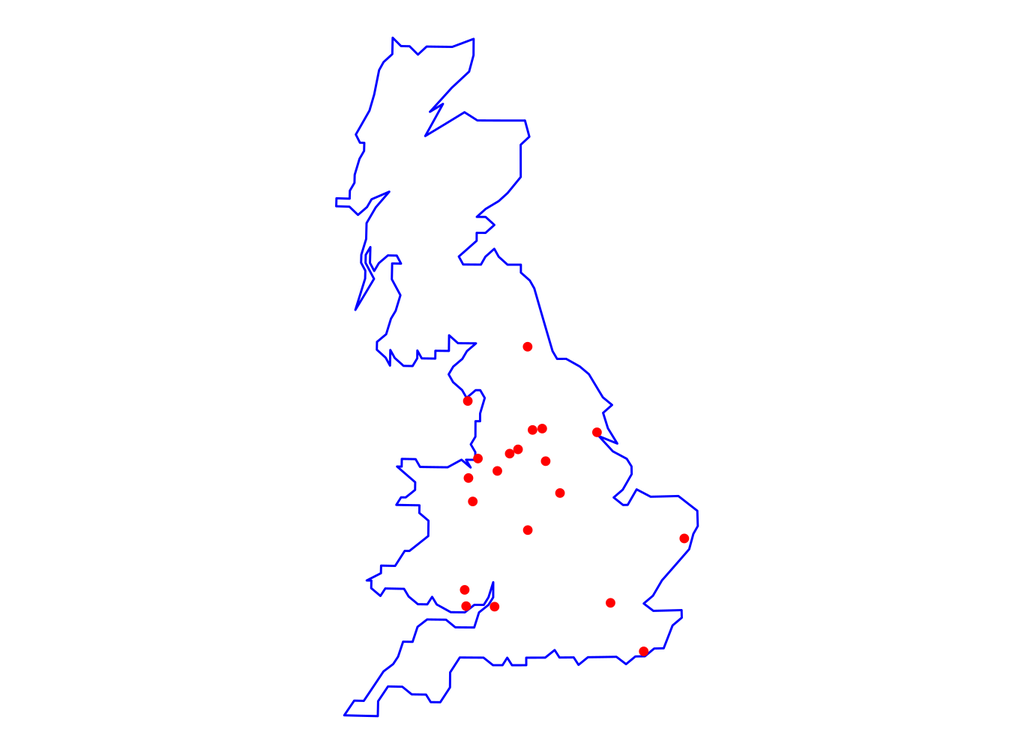

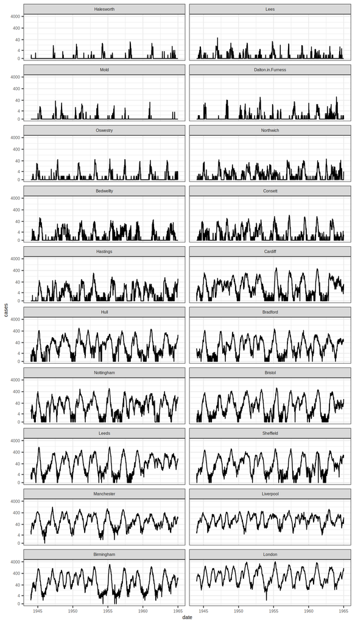

## Model and implementation

### Continuous-time Markov process model

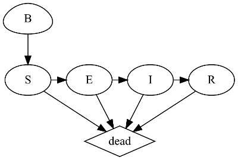

- Covariates:
  - $B(t) = \text{birth rate, from data}$
  - $N(t) = \text{population size, from data}$
- Entry into susceptible class:
  $$\mu_{BS}(t) = (1-c)\,B(t-\tau)+c\,\delta(t-\lfloor t\rfloor)\,\int_{t-1}^{t}\,B(t-\tau-s)\,ds$$
  - $c = \text{cohort effect}$
  - $\tau = \text{school-entry delay}$
  - $\lfloor t \rfloor = \text{most recent 1 September before}\ t$
- Force of infection:
  $$\mu_{SE}(t) = \tfrac{\beta(t)}{N(t)}\,(I+\iota)\,\zeta(t)$$
  - school-term transmission:
    $$\beta(t) = \begin{cases}\beta_0\,(1+a) &\text{during term}\\\beta_0\,(1-a) &\text{during vacation}\end{cases}$$
  - $\iota = \text{imported infections}$
  - $\zeta(t) = \text{Gamma white noise with intensity}\,\sigma_{SE}$ (He et al. 2010, Bhadra et al. 2011)
- Overdispersed binomial measurement model: $\mathrm{cases}_t\,\vert\,{\Delta}{N}_{IR}=z_t \sim \mathrm{Normal}\left(\rho\,z_t,\rho\,(1-\rho)\,z_t+(\psi\,\rho\,z_t)^2\right)$

### Implementation in **pomp**

We’ll load the packages we’ll need, and set the random seed, to allow reproducibility. Note that we’ll be making heavy use of the **tidyverse** methods. Also, we’ll be using **ggplot2** for plotting: see [this brief tutorial](https://kingaa.github.io/R_Tutorial/viz.html#a-more-systematic-approach-the-grammar-of-graphics). Finally, we’ll use the convenient **magrittr** syntax, which is explained [here](https://kingaa.github.io/R_Tutorial/munging.html#the-magrittr-syntax).

```r
library(pomp)
library(tidyverse)
theme_set(theme_bw())
set.seed(594709947L)
```

### Data and covariates

Now we’ll load the data and covariates. The data are measles reports from 20 cities in England and Wales. We also have information on the population sizes and birth-rates in these cities; we’ll treat these variables as covariates.

```r
daturl <- "https://kingaa.github.io/pomp/vignettes/twentycities.rda"
datfile <- file.path(tempdir(),"twentycities.rda")
download.file(daturl,destfile=datfile,mode="wb")
load(datfile)
```

We select the data for London and pre-process the measles and demography data.

```r
measles %>%
  mutate(year=as.integer(format(date,"%Y"))) %>%
  filter(town=="London" & year>=1950 & year<1964) %>%
  mutate(
    time=(julian(date,origin=as.Date("1950-01-01")))/365.25+1950
  ) %>%
  filter(time>1950 & time<1964) %>%
  select(time,cases) -> dat

demog %>%
  filter(town=="London") %>%
  select(-town) -> demogLondon
```

We plot the data and covariates.

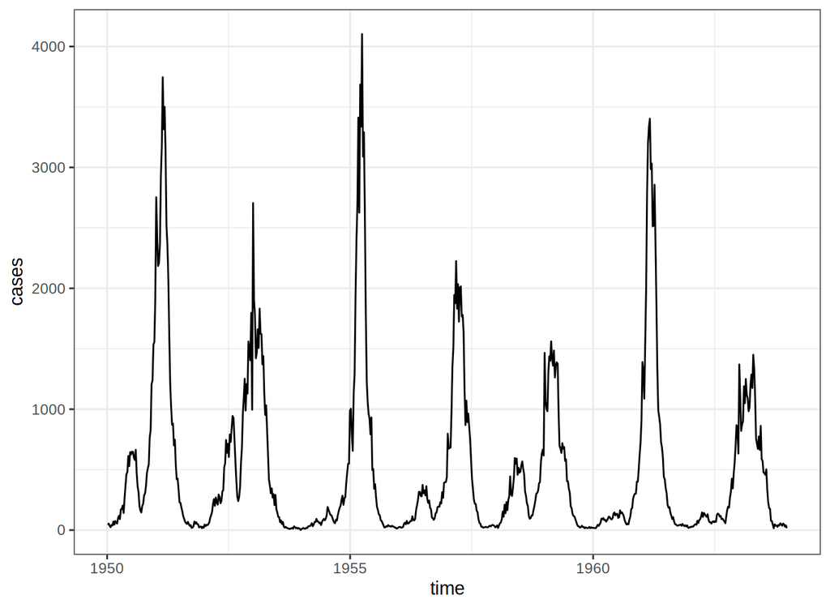

```r
dat %>% ggplot(aes(x=time,y=cases))+geom_line()
```

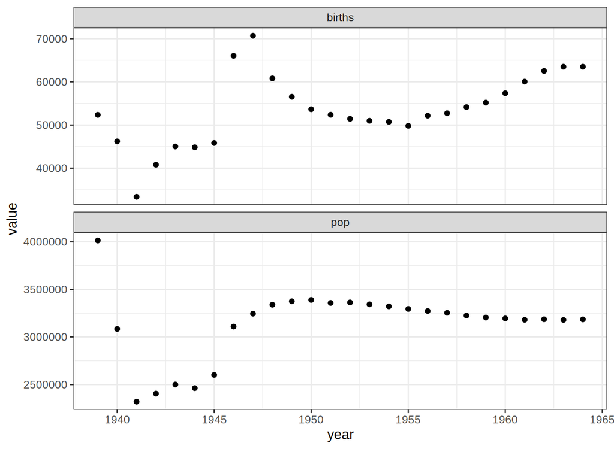

```r
demogLondon %>%
  gather(variable,value,-year) %>%
  ggplot(aes(x=year,y=value))+geom_point()+
  facet_wrap(~variable,ncol=1,scales="free_y")
```

Now, we smooth the covariates. Note that we delay the entry of newborns into the susceptible pool.

```r
demogLondon %>%
  plyr::summarize(
    time=seq(from=min(year),to=max(year),by=1/12),
    pop=predict(smooth.spline(x=year,y=pop),x=time)$y,
    birthrate=predict(smooth.spline(x=year+0.5,y=births),x=time-4)$y
  ) -> covar
```

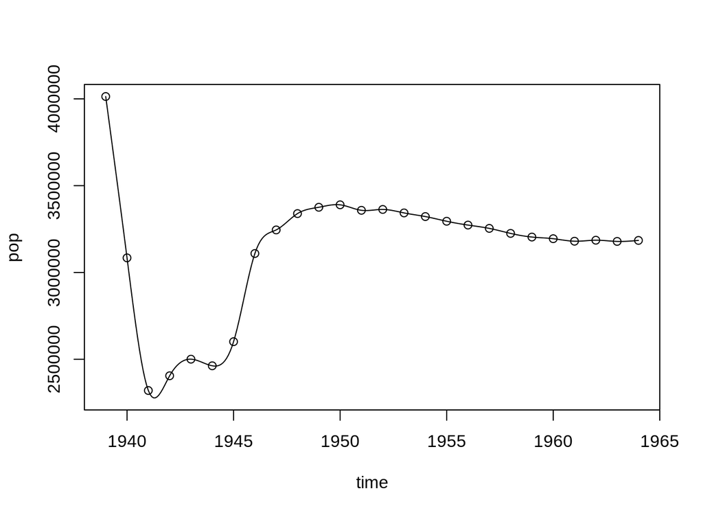

```r
plot(pop~time,data=covar,type='l')
points(pop~year,data=demogLondon)
```

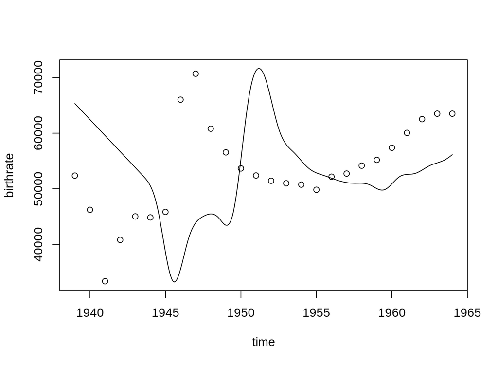

```r
plot(birthrate~time,data=covar,type='l')
points(births~year,data=demogLondon)
```

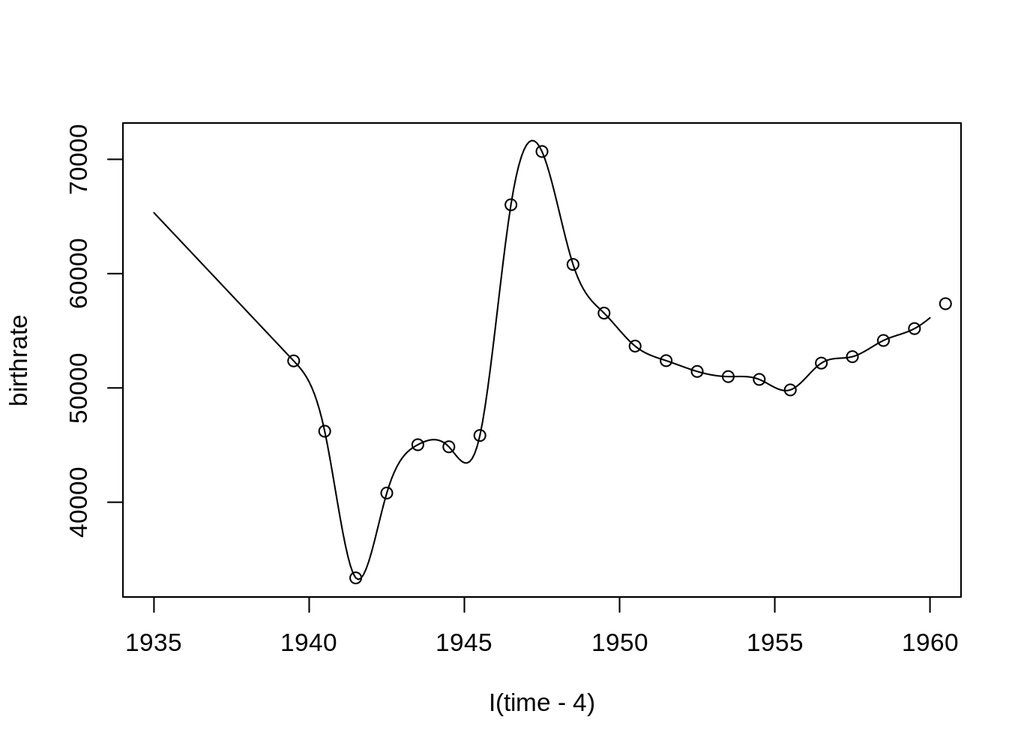

```r
plot(birthrate~I(time-4),data=covar,type='l')
points(births~I(year+0.5),data=demogLondon)
```

### The partially observed Markov process model

#### The (unobserved) process model

We propose a variant of the SEIR model as an explanation for these data. This is a compartmental model that, diagrammatically, looks as follows.

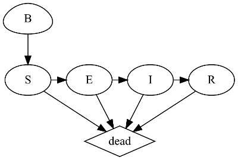

model diagram

$B = \text{births}$  
$S = \text{susceptibles}$  
$E = \text{exposed, incubating}$  
$I = \text{infectious}$  
$R = \text{recovered}$

We require a simulator for this model. The following code implements a simulator.

Notable complexities include:

1. Incorporation of the known birthrate.
2. The birth-cohort effect: a specified fraction (`cohort`) of the cohort enter the susceptible pool aall at once.
3. Seasonality in the transmission rate: during school terms, the transmission rate is higher than it is during holidays.
4. Extra-demographic stochasticity in the form of a Gamma white-noise term acting multiplicatively on the force of infection.
5. Demographic stochasticity implmented using Euler-multinomial distributions.

```r
rproc <- Csnippet("
  double beta, br, seas, foi, dw, births;
  double rate[6], trans[6];

  // cohort effect
  if (fabs(t-floor(t)-251.0/365.0) < 0.5*dt)
    br = cohort*birthrate/dt + (1-cohort)*birthrate;
  else
    br = (1.0-cohort)*birthrate;

  // term-time seasonality
  t = (t-floor(t))*365.25;
  if ((t>=7&&t<=100) || (t>=115&&t<=199) || (t>=252&&t<=300) || (t>=308&&t<=356))
      seas = 1.0+amplitude*0.2411/0.7589;
    else
      seas = 1.0-amplitude;

  // transmission rate
  beta = R0*(gamma+mu)*seas;
  // expected force of infection
  foi = beta*pow(I+iota,alpha)/pop;
  // white noise (extrademographic stochasticity)
  dw = rgammawn(sigmaSE,dt);

  rate[0] = foi*dw/dt;  // stochastic force of infection
  rate[1] = mu;             // natural S death
  rate[2] = sigma;        // rate of ending of latent stage
  rate[3] = mu;             // natural E death
  rate[4] = gamma;        // recovery
  rate[5] = mu;             // natural I death

  // Poisson births
  births = rpois(br*dt);

  // transitions between classes
  reulermultinom(2,S,&rate[0],dt,&trans[0]);
  reulermultinom(2,E,&rate[2],dt,&trans[2]);
  reulermultinom(2,I,&rate[4],dt,&trans[4]);

  S += births   - trans[0] - trans[1];
  E += trans[0] - trans[2] - trans[3];
  I += trans[2] - trans[4] - trans[5];
  R = pop - S - E - I;
  W += (dw - dt)/sigmaSE;  // standardized i.i.d. white noise
  C += trans[4];           // true incidence
")
```

In the above, $C$ represents the true incidence, i.e., the number of new infections occurring over an interval. Since recognized measles infections are quarantined, we argue that most infection occurs before case recognition so that true incidence is a measure of the number of individuals progressing from the I to the R compartment in a given interval.

We complete the process model definition by specifying the distribution of initial unobserved states. The following codes assume that the fraction of the population in each of the four compartments is known.

```r
rinit <- Csnippet("
  double m = pop/(S_0+E_0+I_0+R_0);
  S = nearbyint(m*S_0);
  E = nearbyint(m*E_0);
  I = nearbyint(m*I_0);
  R = nearbyint(m*R_0);
  W = 0;
  C = 0;
")
```

#### The measurement model

We’ll model both under-reporting and measurement error. We want $\mathbb{E}[\text{cases}|C] = \rho\,C$, where $C$ is the true incidence and $0<\rho<1$ is the reporting efficiency. We’ll also assume that $\mathrm{Var}[\text{cases}|C] = \rho\,(1-\rho)\,C + (\psi\,\rho\,C)^2$, where $\psi$ quantifies overdispersion. Note that when $\psi=0$, the variance-mean relation is that of the binomial distribution. To be specific, we’ll choose $\text{cases|C} \sim f(\cdot|\rho,\psi,C)$, where
$$f(c|\rho,\psi,C) = \Phi(c+\tfrac{1}{2},\rho\,C,\rho\,(1-\rho)\,C+(\psi\,\rho\,C)^2)-\Phi(c-\tfrac{1}{2},\rho\,C,\rho\,(1-\rho)\,C+(\psi\,\rho\,C)^2),$$
where $\Phi(x,\mu,\sigma^2)$ is the c.d.f. of the normal distribution with mean $\mu$ and variance $\sigma^2$.

The following computes $\mathbb{P}[\text{cases}|C]$.

```r
dmeas <- Csnippet("
  double m = rho*C;
  double v = m*(1.0-rho+psi*psi*m);
  double tol = 1.0e-18;
  if (cases > 0.0) {
    lik = pnorm(cases+0.5,m,sqrt(v)+tol,1,0)-pnorm(cases-0.5,m,sqrt(v)+tol,1,0)+tol;
  } else {
    lik = pnorm(cases+0.5,m,sqrt(v)+tol,1,0)+tol;
  }
")
```

The following codes simulate $\text{cases} | C$.

```r
rmeas <- Csnippet("
  double m = rho*C;
  double v = m*(1.0-rho+psi*psi*m);
  double tol = 1.0e-18;
  cases = rnorm(m,sqrt(v)+tol);
  if (cases > 0.0) {
    cases = nearbyint(cases);
  } else {
    cases = 0.0;
  }
")
```

#### Constructing the `pomp` object

We put all the model components together with the data in a call to `pomp`:

```r
dat %>%
  pomp(t0=with(dat,2*time[1]-time[2]),
    time="time",
    rprocess=euler(rproc,delta.t=1/365.25),
    rinit=rinit,
    dmeasure=dmeas,
    rmeasure=rmeas,
    covar=covariate_table(covar,times="time"),
    accumvars=c("C","W"),
    statenames=c("S","E","I","R","C","W"),
    paramnames=c("R0","mu","sigma","gamma","alpha","iota",
      "rho","sigmaSE","psi","cohort","amplitude",
      "S_0","E_0","I_0","R_0")
  ) -> m1
```

The following codes plot the data and covariates together.

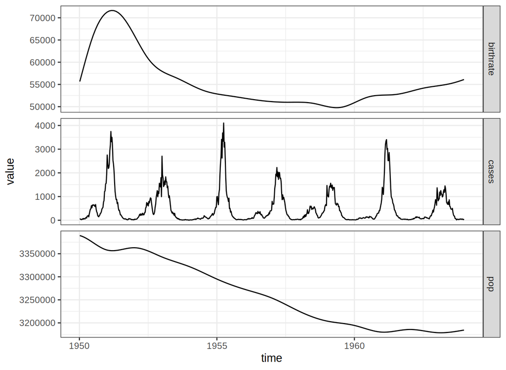

```r
m1 %>%
  as.data.frame() %>%
  gather(variable,value,-time) %>%
  ggplot(aes(x=time,y=value))+
  geom_line()+
  facet_grid(variable~.,scales="free_y")
```

He et al. (2010) estimated the parameters of this model. The full set is included in the *R* code accompanying this document, where they are read into a data frame called `mles`.

```r
mles %>% filter(town=="London") -> mle
paramnames <- c("R0","mu","sigma","gamma","alpha","iota",
  "rho","sigmaSE","psi","cohort","amplitude",
  "S_0","E_0","I_0","R_0")
mle[paramnames] %>% unlist() -> theta
mle %>% select(-S_0,-E_0,-I_0,-R_0)
```

| town | loglik | loglik.sd | mu | delay | sigma | gamma | rho | R0 | amplitude | alpha | iota | cohort | psi | sigmaSE |
| --- | --- | --- | --- | --- | --- | --- | --- | --- | --- | --- | --- | --- | --- | --- |
| London | -3804.9 | 0.16 | 0.02 | 4 | 28.9 | 30.4 | 0.488 | 56.8 | 0.554 | 0.976 | 2.9 | 0.557 | 0.116 | 0.0878 |

```r
library(foreach)
library(doParallel)
library(doRNG)

registerDoParallel()
registerDoRNG(998468235L)

foreach(i=1:4) %dopar% {
  library(pomp)
  pfilter(m1,Np=10000,params=theta)
} -> pfs
logmeanexp(sapply(pfs,logLik),se=TRUE)
```

[output not shown]

Simulations at the MLE:

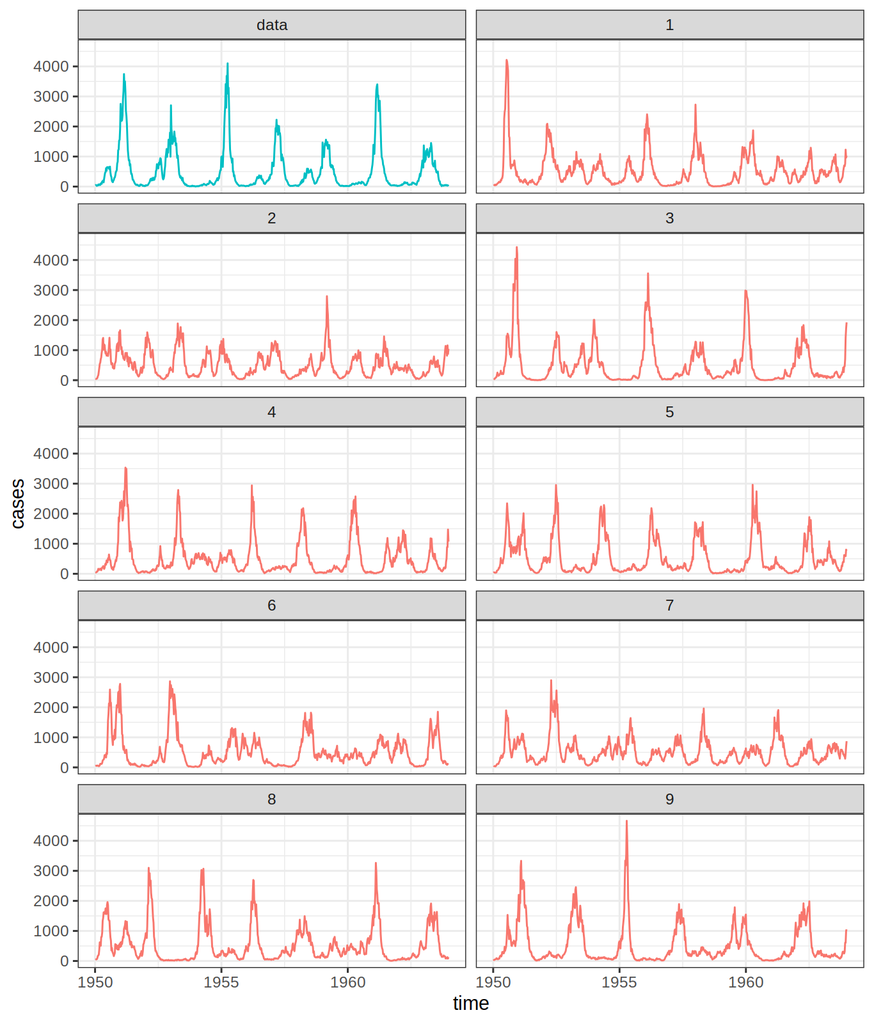

```r
m1 %>%
  simulate(params=theta,nsim=9,format="d",include.data=TRUE) %>%
  ggplot(aes(x=time,y=cases,group=.id,color=(.id=="data")))+
  guides(color=FALSE)+
  geom_line()+facet_wrap(~.id,ncol=2)
```

#### Parameter transformations

The parameters are constrained to be positive, and some of them are constrained to lie between $0$ and $1$. We can turn the likelihood maximization problem into an unconstrained maximization problem by transforming the parameters. Specifically, to enforce positivity, we long transform, to constrain parameters to the unit interval, we logit transform, and to confine parameters to the unit simplex, we use the log-barycentric transformation.

```r
pt <- parameter_trans(
  log=c("sigma","gamma","sigmaSE","psi","R0"),
  logit=c("cohort","amplitude"),
  barycentric=c("S_0","E_0","I_0","R_0")
)

m1 %>%
  pomp(partrans=pt,
    statenames=c("S","E","I","R","C","W"),
    paramnames=c("R0","mu","sigma","gamma","alpha","iota",
      "rho","sigmaSE","psi","cohort","amplitude",
      "S_0","E_0","I_0","R_0")) -> m1
```

### Construction of a likelihood profile

The linked document shows how a likelihood profile can be constructed using IF2.

## Results from He et al. (2010)

### Fitting procedures

- A large number of searches were started at points across the parameter space.
- Iterated filtering was used to maximize the likelihood.
- We obtained point estimates of all parameters for 20 cities.
- We constructed profile likelihoods to quantify uncertainty in London and Hastings.

### Imported infections

$$\text{force of infection} = \mu_{SE}=\frac{\beta(t)}{N(t)}\,(I+\iota)\,\zeta(t)$$

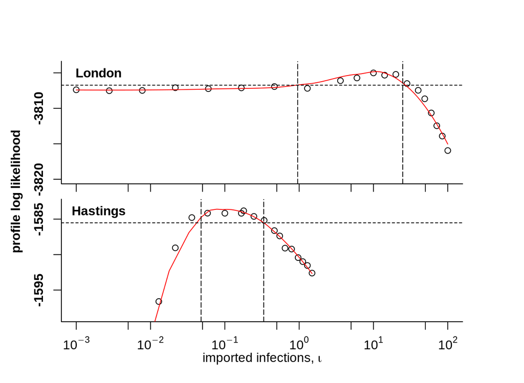

### Seasonality

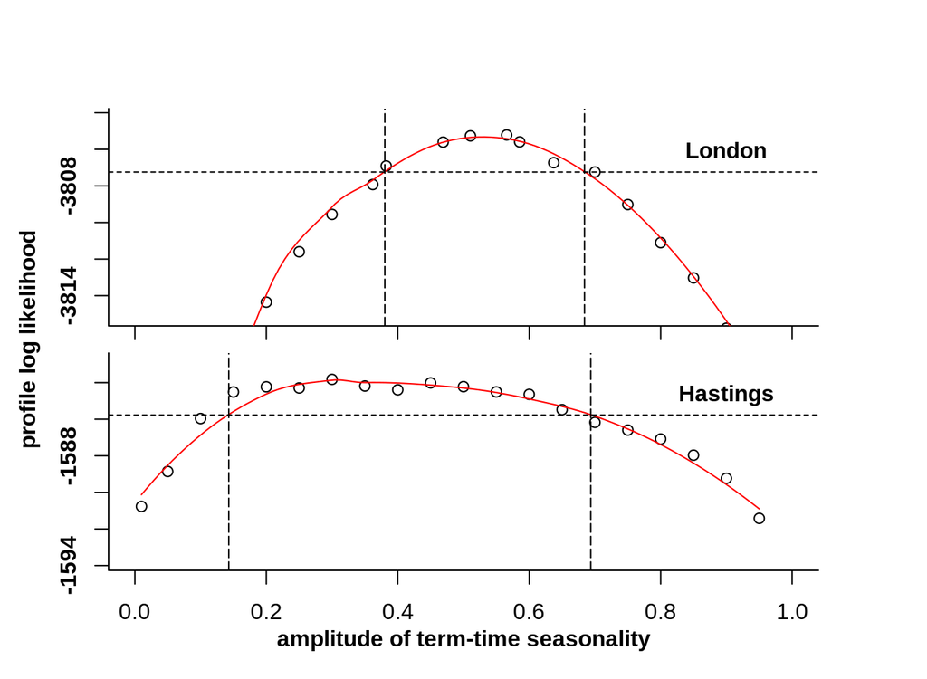

### Notable findings

#### Cohort effect

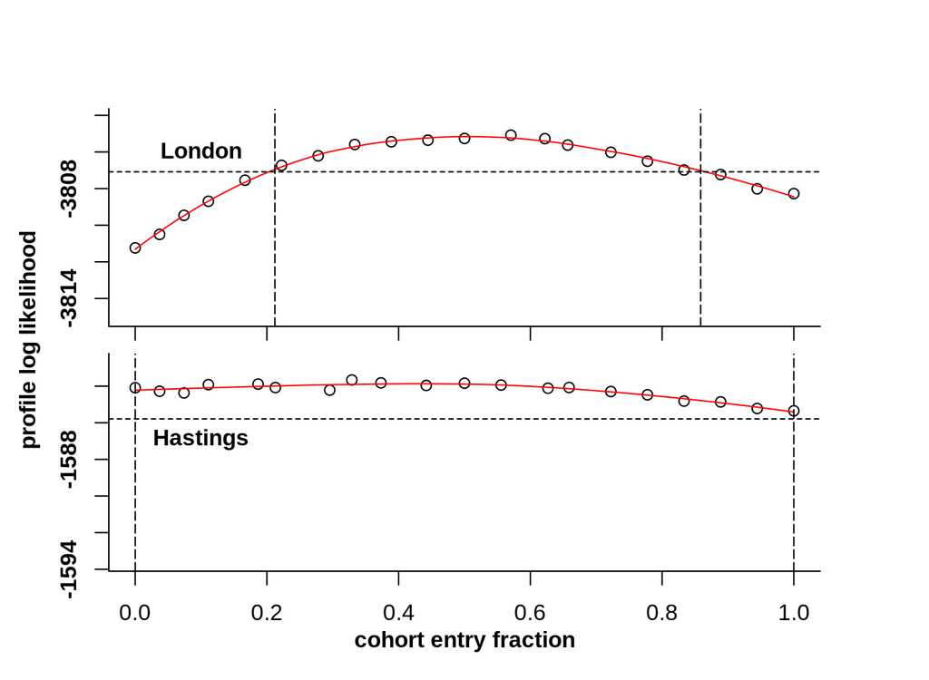

#### Birth delay

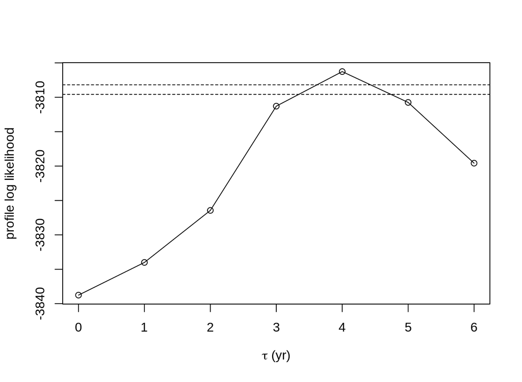

Profile likelihood for birth-cohort delay, showing 95% and 99% critical values of the log likelihood.

#### Reporting rate

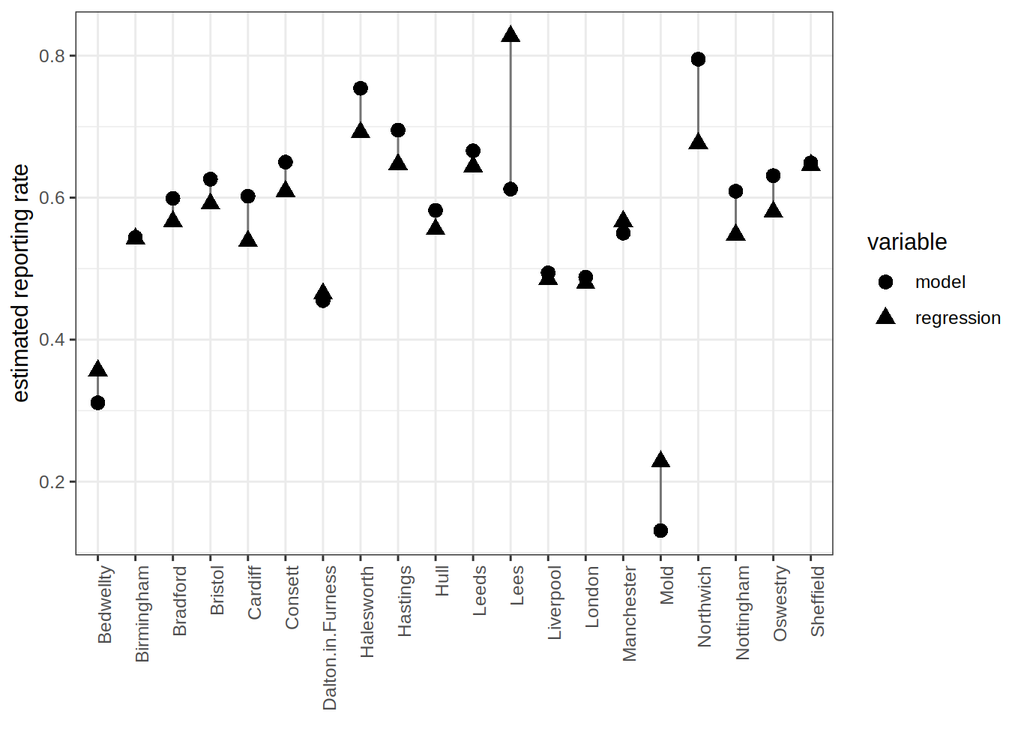

#### Predicted vs observed critical community size

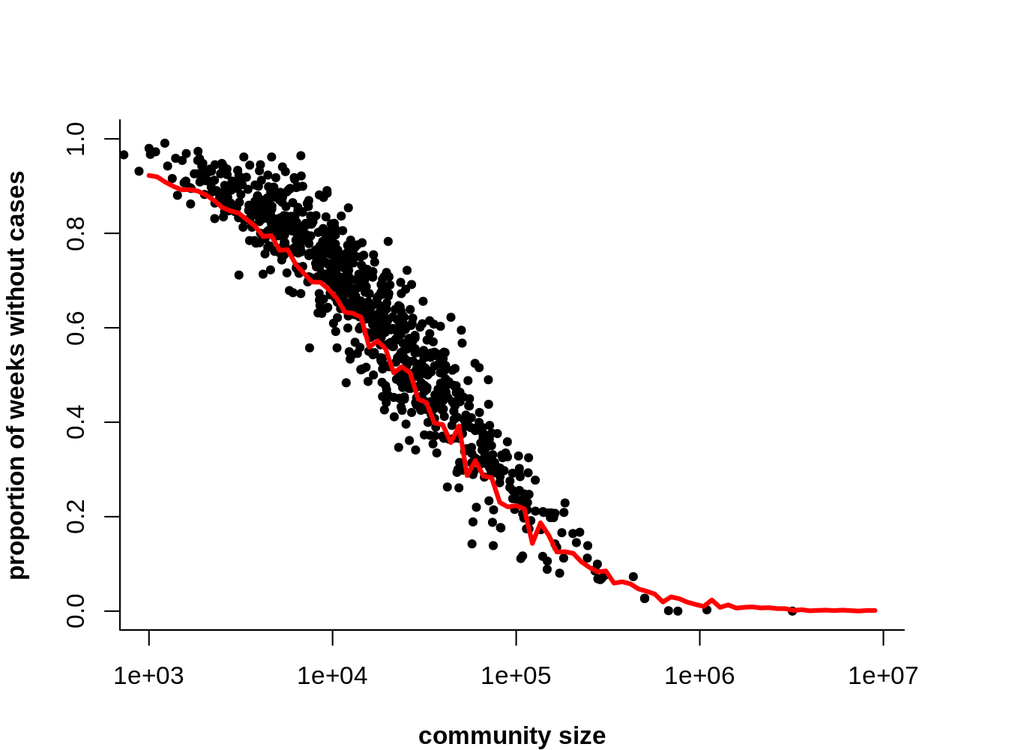

### Problematic results

#### $R_0$

- Recall that $R_0$ is the basic reproduction number: a measure of how communicable an infection is.
- Existing estimates of $R_0$ (c. 15–20) come from two sources:
  - serology surveys
  - models fit to data using feature-based methods

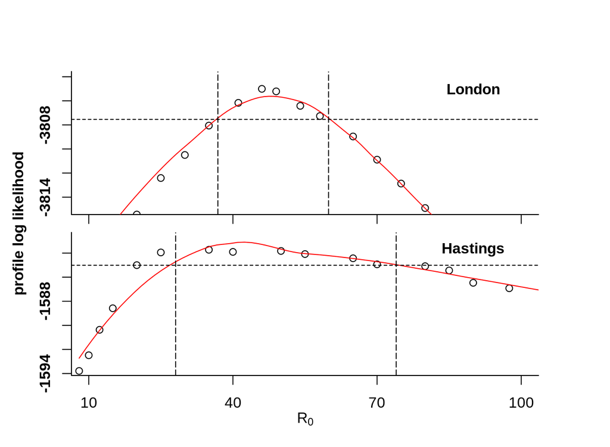

#### Parameter estimates

|  | pop | R0 | amplitude | LP | IP | alpha | iota | rho | psi | sigmaSE |
| --- | --- | --- | --- | --- | --- | --- | --- | --- | --- | --- |
| Halesworth | 2170 | 33.100 | 0.381 | 7.870 | 2.290 | 0.948 | 0.00912 | 0.754 | 0.641 | 0.0748 |
| Lees | 4250 | 29.700 | 0.153 | 8.510 | 2.050 | 0.968 | 0.03110 | 0.612 | 0.681 | 0.0802 |
| Mold | 6410 | 21.400 | 0.271 | 5.930 | 1.780 | 1.040 | 0.01450 | 0.131 | 2.870 | 0.0544 |
| Dalton.in.Furness | 10600 | 28.300 | 0.203 | 5.480 | 1.980 | 0.989 | 0.03860 | 0.455 | 0.818 | 0.0779 |
| Oswestry | 11000 | 52.900 | 0.339 | 10.300 | 2.710 | 1.040 | 0.02980 | 0.631 | 0.476 | 0.0699 |
| Northwich | 18300 | 30.100 | 0.423 | 8.510 | 3.020 | 0.948 | 0.06020 | 0.795 | 0.402 | 0.0857 |
| Bedwellty | 28900 | 24.700 | 0.160 | 6.820 | 3.030 | 0.937 | 0.03960 | 0.311 | 0.951 | 0.0611 |
| Consett | 39100 | 35.900 | 0.200 | 9.080 | 2.660 | 1.010 | 0.07310 | 0.650 | 0.406 | 0.0712 |
| Hastings | 65700 | 34.200 | 0.299 | 7.000 | 5.440 | 1.000 | 0.18600 | 0.695 | 0.396 | 0.0955 |
| Cardiff | 245000 | 34.400 | 0.223 | 9.870 | 3.090 | 0.996 | 0.14100 | 0.602 | 0.270 | 0.0539 |
| Bradford | 294000 | 32.100 | 0.236 | 8.510 | 3.360 | 0.991 | 0.24400 | 0.599 | 0.190 | 0.0451 |
| Hull | 302000 | 38.900 | 0.221 | 9.180 | 5.460 | 0.968 | 0.14200 | 0.582 | 0.256 | 0.0636 |
| Nottingham | 307000 | 22.600 | 0.157 | 5.720 | 3.700 | 0.982 | 0.17000 | 0.609 | 0.258 | 0.0380 |
| Bristol | 443000 | 26.800 | 0.203 | 6.190 | 4.940 | 1.010 | 0.44100 | 0.626 | 0.201 | 0.0392 |
| Leeds | 510000 | 47.800 | 0.267 | 9.480 | 10.900 | 1.000 | 1.25000 | 0.666 | 0.167 | 0.0778 |
| Sheffield | 515000 | 33.100 | 0.313 | 7.230 | 6.380 | 1.020 | 0.85300 | 0.649 | 0.175 | 0.0428 |
| Manchester | 704000 | 32.900 | 0.290 | 11.100 | 6.940 | 0.965 | 0.59000 | 0.550 | 0.161 | 0.0551 |
| Liverpool | 802000 | 48.100 | 0.305 | 7.900 | 9.800 | 0.978 | 0.26300 | 0.494 | 0.136 | 0.0533 |
| Birmingham | 1120000 | 43.400 | 0.428 | 8.510 | 11.600 | 1.010 | 0.34300 | 0.544 | 0.178 | 0.0611 |
| London | 3390000 | 56.800 | 0.554 | 13.100 | 12.500 | 0.976 | 2.90000 | 0.488 | 0.116 | 0.0878 |
| r | NA | 0.455 | 0.301 | 0.322 | 0.946 | 0.106 | 0.93200 | -0.203 | -0.931 | -0.3260 |

$r = \mathrm{cor}(\log{\hat\theta},\log{N_{1950}})$

#### Extrademographic stochasticity

$$\mu_{SE}=\frac{\beta(t)}{N(t)}\,(I+\iota)\,\zeta(t)$$

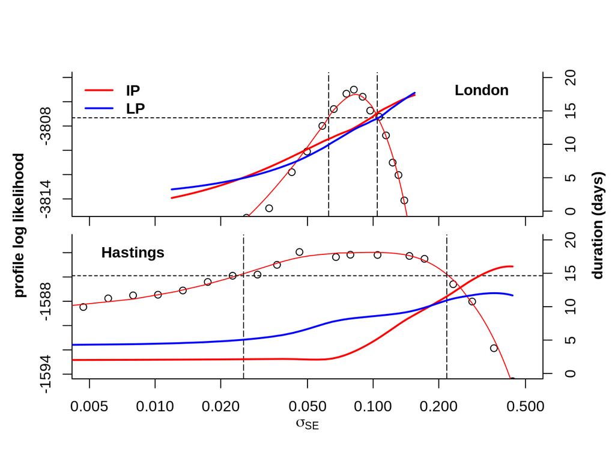

### Questions

1. What does it mean that parameter estimates from the fitting disagree with estimates from other data?
2. How can one interpret the correlation between infectious period and city size in the parameter estimates?
3. How do we interpret the need for extrademographic stochasticity in this model?

Simulations at the MLE:

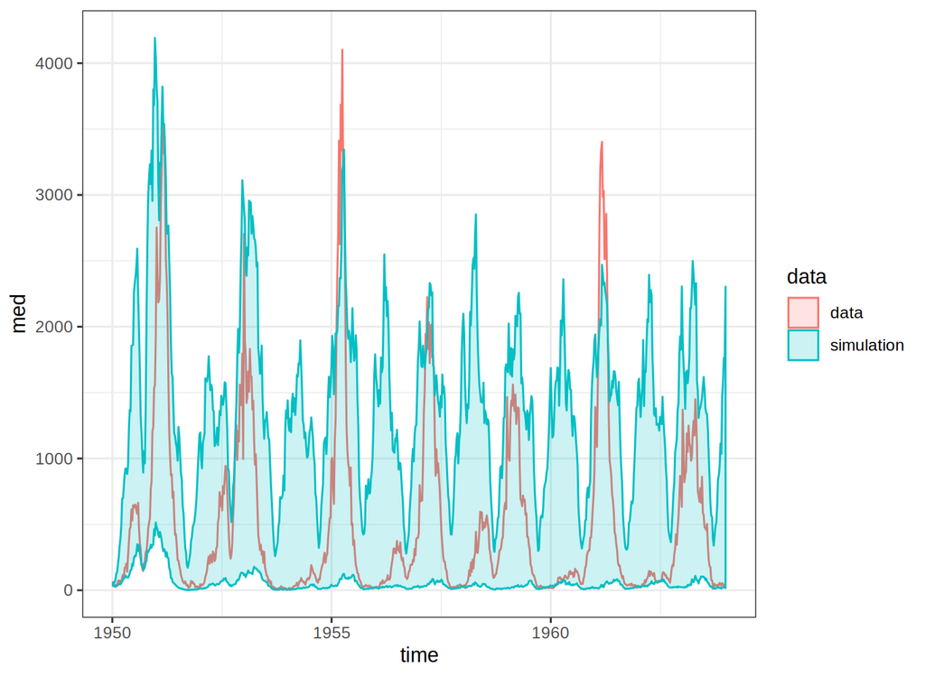

```r
m1 %>%
  simulate(params=theta,nsim=100,format="d",include.data=TRUE) %>%
  select(time,.id,cases) -> simdat

simdat %>%
  mutate(data=.id=="data") %>%
  plyr::ddply(~time+data,plyr::summarize,
    p=c(0.05,0.5,0.95),
    q=quantile(cases,prob=p,names=FALSE)
  ) %>%
  mutate(p=plyr::mapvalues(p,from=c(0.05,0.5,0.95),to=c("lo","med","hi")),
         data=plyr::mapvalues(data,from=c(TRUE,FALSE),to=c("data","simulation"))) %>%
  spread(p,q) %>%
  ggplot(aes(x=time,y=med,color=data,fill=data,ymin=lo,ymax=hi))+
  geom_ribbon(alpha=0.2)+
  guides(data=FALSE)
```

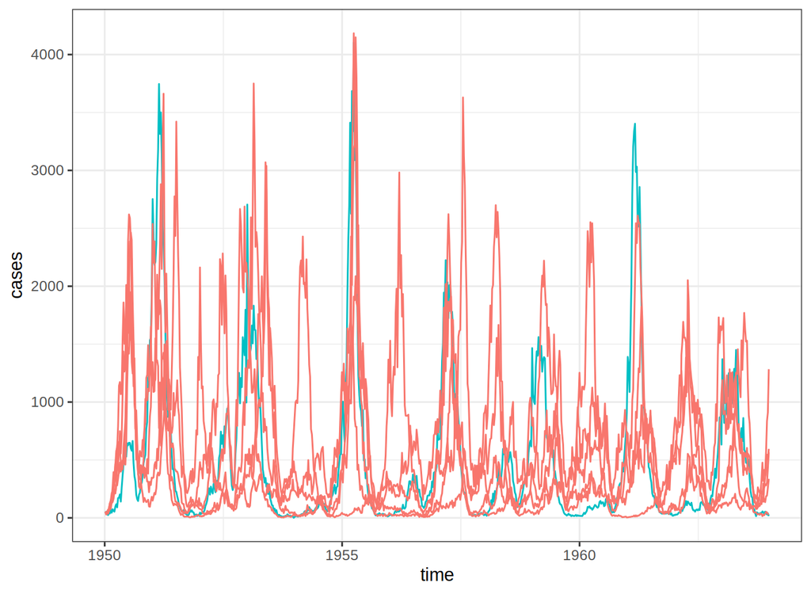

```r
simdat %>%
  filter(.id=="data" | .id <= "5") %>%
  mutate(data=.id=="data") %>%
  ggplot(aes(x=time,y=cases,group=.id,color=data))+
  geom_line()+
  guides(color=FALSE)
```

## Exercises

### Exercise: Reformulate the model

Modify the He et al. (2010) model to remove the cohort effect. Run simulations and compute likelihoods to convince yourself that the resulting codes agree with the original ones for `cohort = 0`.

Now modify the transmission seasonality to use a sinusoidal form. How many parameters must you use? Fixing the other parameters at their MLE values, compute and visualize a profile likelihood over these parameters.

### Exercise: Extrademographic stochasticity

Set the extrademographic stochasticity parameter $\sigma_{SE}=0$, set $\alpha=1$, and fix $\rho$ and $\iota$ at their MLE values, then maximize the likelihood over the remaining parameters. How do your results compare with those at the MLE? Compare likelihoods but also use simulations to diagnose differences between the models.

## [**R** codes for this document](https://raw.githubusercontent.com/kingaa/sbied/master/measles/measles.R)

## Profile likelihood computation for this example

## References

Bhadra, A., E. L. Ionides, K. Laneri, M. Pascual, M. Bouma, and R. Dhiman. 2011. Malaria in Northwest India: Data analysis via partially observed stochastic differential equation models driven by Lévy noise. Journal of the American Statistical Association 106:440–451.

He, D., E. L. Ionides, and A. A. King. 2010. Plug-and-play inference for disease dynamics: Measles in large and small populations as a case study. Journal of the Royal Society, Interface 7:271–283.

Rohani, P., and A. A. King. 2010. Never mind the length, feel the quality: The impact of long-term epidemiological data sets on theory, application and policy. Trends in Ecology & Evolution 25:611–618.